# Buffer Optimization

# Gatting strategies

> The following gaphing steps are used to gate singlets by FSC and SSC values. Only singlets are included in analysis.

## Gate for singlets

Gate for outlier

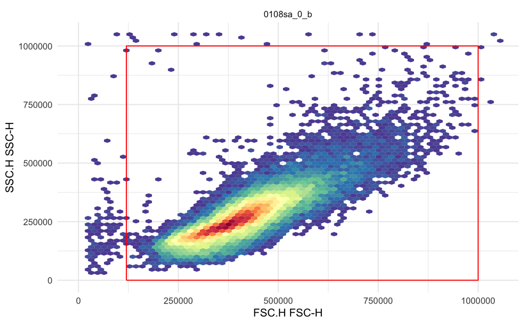

```r
outlier.gate <- rectangleGate(filterId = "-outlier", "FSC.H" = c(1.2e5, 1e6), "SSC.H" = c(1e2, 1e6))
ggcyto(dat[13], aes(x = FSC.H, y = SSC.H), subset = "root") +
  geom_hex(bins = 64) + geom_gate(outlier.gate) + facet_wrap(~name, ncol = 2) + ggcyto_par_set(limits = "instrument")
```

Add gate to GS

```r
# create a GatingSet
gs <- GatingSet(dat)
# add root gate
gs_pop_add(gs, outlier.gate, parent = "root")
```

```
[1] 2
```

```r
recompute(gs)
```

Gate for singlets

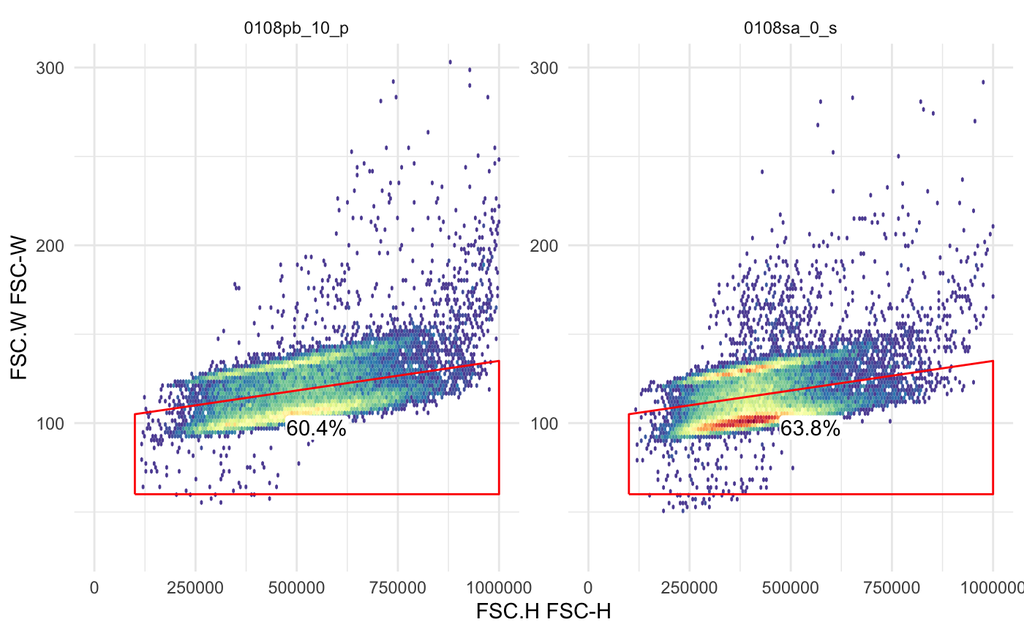

```r
scPars <- ggcyto_par_set(limits = list(x = c(0,1e6), y = c(30,300)))
ex <- Subset(dat[c(5, 15)], outlier.gate)
polygon <- matrix(c(1e5, 1e5, 1e6, 1e6,
                    60, 105, 135,60), ncol = 2)
colnames(polygon) <- c("FSC.H", "FSC.W")
singlet.gate <- polygonGate(filterId = "singlet", .gate = polygon)
ggcyto(ex, aes(x = FSC.H, y = FSC.W)) + geom_hex(bins = 128) + geom_gate(singlet.gate) + geom_stats() + scPars
```

Add this gate to the gatingSet

```r
gs_pop_add(gs, singlet.gate, parent = "-outlier", name = "singlet")
```

```
[1] 3
```

```r
recompute(gs)
```

## Gate for the unstained population

> Unstained population is defined as population below 10^2 in both channels (in the noise range).

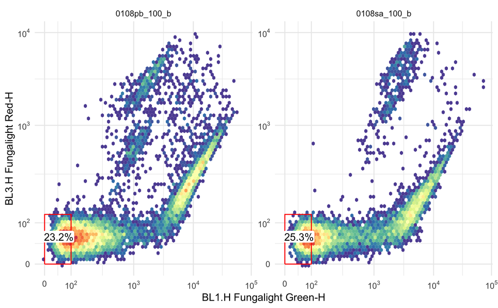

```r
#scPars <- ggcyto_par_set(limits = list(x = c(0,1e6), y = c(0,1e6)))
select <- c(7,19)
ex <- Subset(dat[select], singlet.gate)
polygon2 <- matrix(c(0, 10^2, 10^2, 0,
                    0, 0, 10^2.1, 10^2.1), ncol = 2)
colnames(polygon2) <- c("BL1.H", "BL3.H")
unstained.gate <- polygonGate(filterId = "unstained", .gate = polygon2)
ggcyto(ex, aes(x = BL1.H, y = BL3.H)) +
  geom_hex(bins = 64) +
  geom_gate(unstained.gate) + geom_stats() +# scPars +
  scale_x_logicle() + scale_y_logicle()
```

## Gate for the dead-like population

> Dead population is defined based on 1M treated sample.

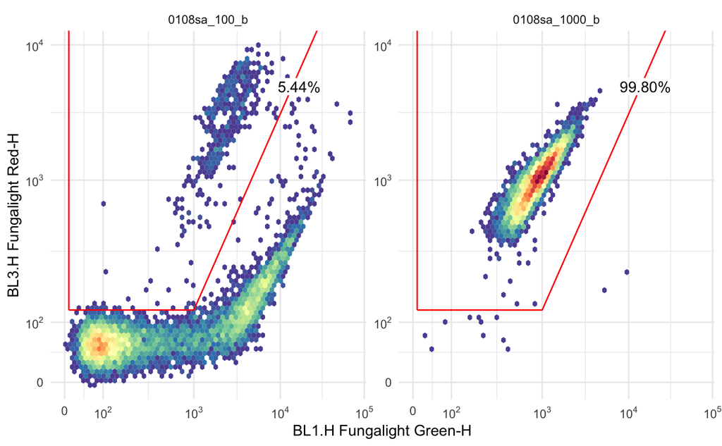

```r
#scPars <- ggcyto_par_set(limits = list(x = c(0,1e6), y = c(0,1e6)))
select <- c(19,22)
ex <- Subset(dat[select], singlet.gate)
polygon <- matrix(c(10^1, 10^3, 10^4.5, 10^1,
                    10^2.1, 10^2.1, 10^4.2, 10^4.2), ncol = 2)
#polygon <- matrix(c(10^2, 10^3, 10^4.5, 10^2.5,
#                    10^2.3, 10^2.3, 10^4, 10^4), ncol = 2)
colnames(polygon) <- c("BL1.H", "BL3.H")
dead.gate <- polygonGate(filterId = "dead_like", .gate = polygon)
ggcyto(ex, aes(x = BL1.H, y = BL3.H)) +
  geom_hex(bins = 64) +
  geom_gate(dead.gate) + geom_stats() + #scPars +
  scale_x_logicle() + scale_y_logicle()
```

# Analysis & Plots

## Visualize one set of data

With gates

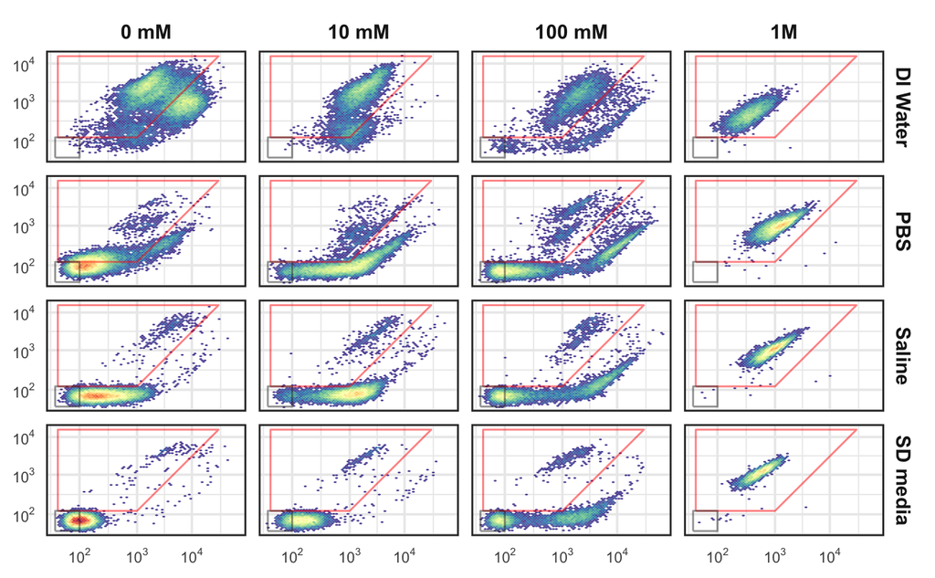

```r
subset.to.plot <- with(pData(gs), dye == "Both" & date == '2024-01-08')
p <- ggcyto(gs[subset.to.plot],
            aes(x = BL1.H, y = BL3.H), subset = "singlet") +
  #geom_hex(aes(fill = after_stat(density)), bins = 64) +
  geom_hex(bins = 64) +
  geom_gate("dead_like", linewidth = 0.5, alpha = 0.5) +
  #geom_stats(type = "percent", location = "gate", adjust = c(0.02, 1),
  #           digits = 1, size = 3) +
  geom_gate("unstained", linewidth = 0.5, alpha = 0.5, colour = "gray20") +
  #geom_stats(type = "percent", location = "data", adjust = c(0.2, 0.003),
  #           digits = 1, size = 3) +
  facet_grid(buffer ~ treatment,
             labeller = as_labeller(c(tr.levels, bu.levels), multi_line = F)) +
  scale_x_logicle(breaks = c(10^2, 10^3, 10^4)) +
  scale_y_logicle(breaks = c(10^2, 10^3, 10^4)) +
  theme_minimal(base_size = 14) +
  panel_border(color = "gray20") + #background_grid(major = "none", minor = "none") +
  theme(
    #axis.line = element_blank(),
    strip.text.y = element_text(face = 2),
    strip.text.x = element_text(face = 2),
    axis.text = element_text(size = rel(0.6)),
    plot.title = element_blank(),
    legend.position = "none",
    axis.title = element_blank()
  )
p
```

save the plot

```r
ggsave("../output/fig2-compare-staining-buffers-with-gate-20260617.png",
       plot = p,
       width = 5, height = 5)
```

Without gates

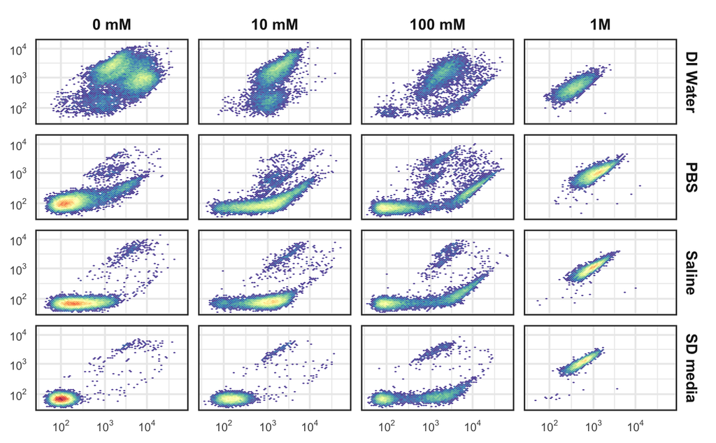

```r
subset.to.plot <- with(pData(gs), dye == "Both" & date == '2024-01-08')
p <- ggcyto(gs[subset.to.plot],
            aes(x = BL1.H, y = BL3.H), subset = "singlet") +
  #geom_hex(aes(fill = after_stat(ndensity)), bins = 64) +
  geom_hex(bins = 64) +
  facet_grid(buffer ~ treatment,
             labeller = as_labeller(c(tr.levels, bu.levels), multi_line = F)) +
  scale_x_logicle(breaks = c(10^2, 10^3, 10^4)) +
  scale_y_logicle(breaks = c(10^2, 10^3, 10^4)) +
  theme_minimal(base_size = 14) +
  panel_border(color = "gray20") + #background_grid(major = "none", minor = "none") +
  theme(
    #axis.line = element_blank(),
    strip.text.y = element_text(face = 2),
    strip.text.x = element_text(face = 2),
    axis.text = element_text(size = rel(0.6)),
    plot.title = element_blank(),
    legend.position = "none",
    axis.title = element_blank()
  )
p
```

save the plot

```r
ggsave("../output/fig2-compare-staining-buffers-no-gate-20260617.png",
       plot = p, width = 5, height = 5)
```

## Export gated event counts

```r
tmp <- gs_pop_get_stats(gs) %>%
  mutate(pop = gsub(".*/", "", pop), pop = gsub("-outlier", "cells", pop)) %>%
  pivot_wider(names_from = pop, names_prefix = "n_", values_from = count) %>%
  mutate(
    p_dead_like = n_dead_like / n_singlet,
    p_unstained = n_unstained / n_singlet
  )

gated_stats <- left_join(
  as_tibble(pData(gs)),
  tmp,
  by = c("name" = "sample")
) %>% dplyr::filter(dye == "Both") %>% select(-dye)

print(gated_stats)
write_tsv(gated_stats, file = "../output/fig2-compare-staining-buffer-gated-stats.tsv")
```

[output not shown]

## Sample-to-sample variation

Visaulize sample-to-sample variability in mock-treated cells across three replicates

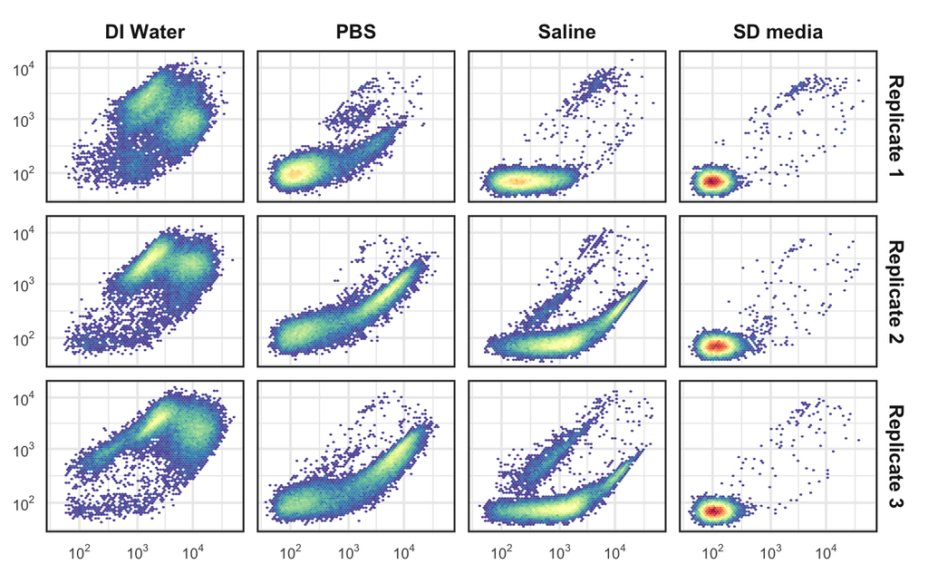

```r
subset.to.plot <- with(pData(gs), dye == "Both" & treatment == "0")
date.levels = paste("Replicate", 1:3); names(date.levels) = unique(sample$date)
p <- ggcyto(gs[subset.to.plot],
            aes(x = BL1.H, y = BL3.H), subset = "singlet") +
  geom_hex(aes(fill = after_stat(density)), bins = 64) +
  facet_grid(date~buffer, labeller = as_labeller(c(date.levels, bu.levels),
                                                   multi_line = F)) +
  scale_x_logicle(breaks = c(10^2, 10^3, 10^4)) +
  scale_y_logicle(breaks = c(10^2, 10^3, 10^4)) +
  theme_minimal(base_size = 14) +
  panel_border(color = "gray20") + #background_grid(major = "none", minor = "none") +
  theme(
    #axis.line = element_blank(),
    strip.text.y = element_text(face = 2),
    strip.text.x = element_text(face = 2),
    axis.text = element_text(size = rel(0.6)),
    plot.title = element_blank(),
    legend.position = "none",
    axis.title = element_blank()
  )
p
```

## Plot percentages and testing for differences

We will primarily look at the mock sample, as the purpose of the buffer comparison is to find a buffer that will minimize the dead-like and unstained populations.

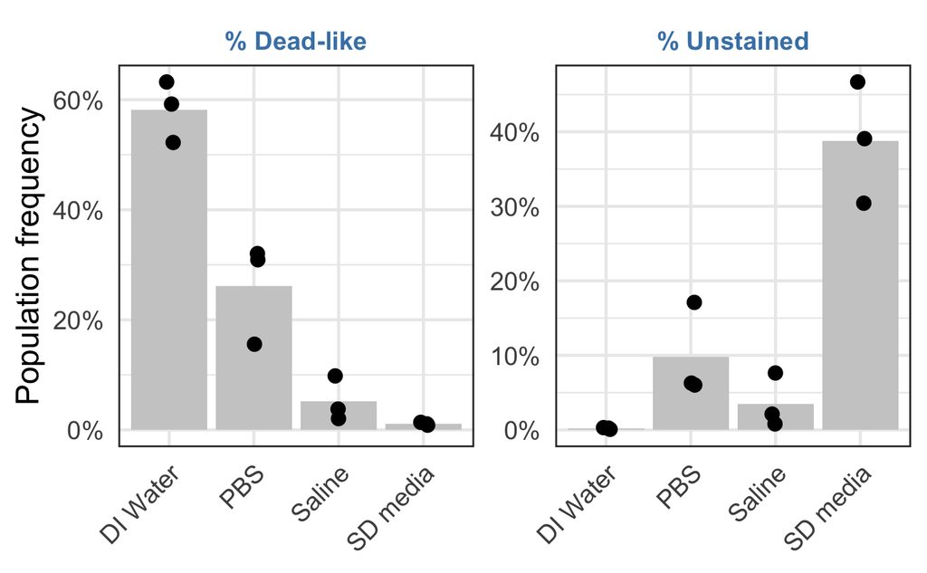

```r
p1 <- gated_stats %>%
  # plot the mock sample only
  dplyr::filter(treatment == "0") %>%
  pivot_longer(
    cols = starts_with("p_"),
    names_to = "var",
    values_to = "value"
  ) %>%
  ggplot(aes(x = buffer, y = value))  +
  geom_bar(stat = "summary", fun = "mean", fill = "gray80") +
  geom_point(size = 3, position = position_jitter(0.05)) +
  scale_y_continuous(labels = scales::percent_format()) +
  scale_x_discrete(labels = bu.levels) +
  facet_wrap(~var, nrow = 2, scales = "free_y", labeller = as_labeller(
    c("p_dead_like" = "% Dead-like", "p_unstained" = "% Unstained"))) +
  labs(x = NULL, y = "Population frequency") +
  theme_minimal(base_size = 18) + panel_border(color = "gray20") +
  theme(axis.text.x = element_text(angle = 45, hjust = 1),
        strip.text = element_text(color = "steelblue", face = 2))
print(p1 + facet_wrap(~var, ncol = 2, scales = "free_y", labeller = as_labeller(
    c("p_dead_like" = "% Dead-like", "p_unstained" = "% Unstained"))))
```

save the plot

```r
ggsave(filename = "../output/fig2bc-compare-buffer-plot-stats.png",
       plot = p1, width = 4, height = 7)
```

### Statistical test for mean

We perform pairwise comparisons for both %dead like and %unstained

Use Tukey HSD test to compare all pairs of conditions for %dead-like

```r
tmp <- gated_stats |>
  dplyr::filter(treatment == "0")
test <- aov(p_dead_like ~ buffer, data = tmp)
TukeyHSD(test)
```

```
  Tukey multiple comparisons of means
    95% family-wise confidence level

Fit: aov(formula = p_dead_like ~ buffer, data = tmp)

$buffer
                       diff        lwr         upr     p adj
PBS-ddH2O       -0.31958392 -0.4696541 -0.16951377 0.0006151
Saline-ddH2O    -0.52940674 -0.6794769 -0.37933659 0.0000159
SD media-ddH2O  -0.57032703 -0.7203972 -0.42025688 0.0000091
Saline-PBS      -0.20982282 -0.3598930 -0.05975267 0.0088963
SD media-PBS    -0.25074311 -0.4008133 -0.10067296 0.0030395
SD media-Saline -0.04092028 -0.1909904  0.10914987 0.8185312
```

Use Tukey HSD test to compare all pairs of conditions for % unstained

```r
tmp <- gated_stats |>
  dplyr::filter(treatment == "0")
test <- aov(p_unstained ~ buffer, data = tmp)
TukeyHSD(test)
```

```
  Tukey multiple comparisons of means
    95% family-wise confidence level

Fit: aov(formula = p_unstained ~ buffer, data = tmp)

$buffer
                       diff         lwr        upr     p adj
PBS-ddH2O        0.09623032 -0.04680483 0.23926547 0.2155341
Saline-ddH2O     0.03330565 -0.10972951 0.17634080 0.8760391
SD media-ddH2O   0.38550289  0.24246774 0.52853805 0.0001166
Saline-PBS      -0.06292467 -0.20595982 0.08011048 0.5281537
SD media-PBS     0.28927257  0.14623742 0.43230773 0.0008740
SD media-Saline  0.35219725  0.20916210 0.49523240 0.0002230
```

### Statistical test for variance

We would like to know if the four buffers differ in terms of sample-to-sample variability. We can use the Brown-Forsythe test to compare the variance across groups. This test uses median instead of mean when calculating the spread and is considered more robust to non-normality than the Levene’s test.

First, calculate the variance for each group

```r
# first, calculate the variance for each group
tmp |>
  group_by(buffer) |>
  summarise(
    var_dead = var(p_dead_like),
    mad_dead = mad(p_dead_like),
    var_unstained = var(p_unstained),
    mad_unstained = mad(p_unstained),
    .groups = "drop"
  )
```

| buffer | var_dead | mad_dead | var_unstained | mad_unstained |
| --- | --- | --- | --- | --- |
| PBS | 8.436846e-03 | 0.01762466 | 4.012443e-03 | 0.0040508618 |
| SD media | 6.809056e-06 | 0.00284868 | 6.636368e-03 | 0.1128416861 |
| Saline | 1.653601e-03 | 0.02509350 | 1.320015e-03 | 0.0196448511 |
| ddH2O | 3.079295e-03 | 0.05942108 | 1.298674e-06 | 0.0008648196 |

Now, perform the Brown–Forsythe test for %dead-like and %unstained

```r
onewaytests::bf.test(p_dead_like ~ buffer, data = tmp)
```

```
    Brown-Forsythe Test

data:  p_dead_like and buffer
F = 61.947, num df = 3.0000, denom df = 4.1637, p-value = 0.0006632
```

```r
onewaytests::bf.test(p_unstained ~ buffer, data = tmp)
```

```
    Brown-Forsythe Test

data:  p_unstained and buffer
F = 30.966, num df = 3.0000, denom df = 4.6308, p-value = 0.001678
```

> although there is clear evidence of unequal variance, the buffer showing the lowest variance is the one that produces near-zero events in the corresponding population, not because that buffer reduces sample-to-sample variability but because it reduces the population itself. Therefore, we will not use variance as a criterion for buffer selection.

## Supplementary plots

PI-alone

```r
subset.to.plot <- with(pData(gs), dye == "PI" & date == '2024-01-09')
p <- ggcyto(gs[subset.to.plot],
            aes(x = BL1.H, y = BL3.H), subset = "singlet") +
  geom_hex(aes(fill = after_stat(density)), bins = 64) +
  facet_grid(buffer ~ treatment,
             labeller = as_labeller(c(tr.levels, bu.levels), multi_line = F)) +
  scale_x_logicle(breaks = c(10^2, 10^3, 10^4)) +
  scale_y_logicle(breaks = c(10^2, 10^3, 10^4)) +
  theme_minimal(base_size = 14) +
  panel_border(color = "gray20") + #background_grid(major = "none", minor = "none") +
  theme(
    #axis.line = element_blank(),
    strip.text.y = element_text(face = 2),
    strip.text.x = element_text(face = 2),
    axis.text = element_text(size = rel(0.6)),
    plot.title = element_blank(),
    legend.position = "none",
    axis.title = element_blank()
  )
print(p)
ggsave("../output/fig2sup-compare-staining-buffers-PI-only-20240923.png", width = 5, height = 5)
```

[output not shown]

SYTO9 alone

```r
subset.to.plot <- with(pData(gs), dye == "SYTO9" & date == '2024-01-09')
p <- ggcyto(gs[subset.to.plot],
            aes(x = BL1.H, y = BL3.H), subset = "singlet") +
  geom_hex(aes(fill = after_stat(density)), bins = 128) +
  facet_grid(buffer ~ treatment,
             labeller = as_labeller(c(tr.levels, bu.levels), multi_line = F)) +
  scale_x_logicle(breaks = c(10^2, 10^3, 10^4)) +
  scale_y_logicle(breaks = c(10^2, 10^3, 10^4)) +
  theme_minimal(base_size = 14) +
  panel_border(color = "gray20") + #background_grid(major = "none", minor = "none") +
  theme(
    #axis.line = element_blank(),
    strip.text.y = element_text(face = 2),
    strip.text.x = element_text(face = 2),
    axis.text = element_text(size = rel(0.6)),
    plot.title = element_blank(),
    legend.position = "none",
    axis.title = element_blank()
  )
print(p)
ggsave("../output/fig2sup-compare-staining-buffers-SYTO9-only-20240923.png", width = 5, height = 5)
```

[output not shown]